# Data Wrangling, Data Analysis, and Data Visualization

Alvaro Guevara

## Hate Crimes vs. Partisan Lean Across States

### Introduction

The two datasets I have chosen are related to state information on the number of hate crimes and the political parties they lean to. I chose these datasets because I was interested to see and investigate if a state’s partisan lean is connected to its average hate crimes in any way. This interest of mine coming from the divisiveness and tension of today’s political atmosphere that has remained even after the end of the last presidency. The ID variable in common is ‘state’. In the ‘partisan_lean_state’ dataset, the variables include states partisan lean represented by ‘pvi_party’ and partisan voting index represented by ‘pvi_amount’. In the ‘hate_crimes’ dataset, some of the variables include median household income represented by ‘median_house_inc’, hate crimes per 100,000 population represented by ‘hate_crimes_per_100k_splc’, and average annual hate crimes per 100,000 represented by avg_hatecrimes_per_100k_fbi". The datasets are from the FiveThirtyEight package in R.

```r
# read datasets
library(fivethirtyeight)
hatecrimes <- hate_crimes
stateparties <- partisan_lean_state
```

### Tidying: Reshaping

```r
# tidyverse
library(tidyverse)

# untidy 'hatecrimes' dataset with pivot_wider and then
# retidy it with pivot_longer save as a new object
hatecrimes1 <- hatecrimes %>% pivot_wider(names_from = "state",
    values_from = "share_vote_trump")
hatecrimes1 <- hatecrimes1 %>% pivot_longer(12:62, names_to = "state",
    values_to = "share_vote_trump", values_drop_na = T) %>% relocate(state,
    .before = state_abbrev) %>% relocate(share_vote_trump, .before = hate_crimes_per_100k_splc)

## untidy 'stateparties' dataset with pivot_wider and then
## retidy it with pivot_longer save as a new object
stateparties1 <- partisan_lean_state %>% pivot_wider(names_from = "state",
    values_from = "pvi_party")
stateparties1 <- stateparties1 %>% pivot_longer(2:51, names_to = "state",
    values_to = "pvi_party", values_drop_na = T) %>% arrange(state) %>%
    relocate(state, pvi_party, .before = pvi_amount)
```

### Joining/Merging

```r
# how many observations/rows
nrow(hatecrimes1)
```

```
## [1] 51
```

```r
nrow(stateparties1)
```

```
## [1] 50
```

```r
# distinct IDs in each original dataset
nrow(distinct(hatecrimes1))
```

```
## [1] 51
```

```r
nrow(distinct(stateparties1))
```

```
## [1] 50
```

There were 51 observations/rows in the ‘hatecrimes1’ dataset, as well as 51 unique IDs. There were 50 observations/rows in the ‘stateparties1’ dataset, as well as 50 unique IDs.

```r
# How many IDs are in `hatecrimes1` that do not appear in
# `stateparties1`?
hatecrimes1 %>% anti_join(stateparties1, by = "state")
```

```
## # A tibble: 1 x 13
##   state state_abbrev median_house_inc share_unemp_seas share_pop_metro
##   <chr> <chr>                   <int>            <dbl>           <dbl>
## 1 Dist… DC                      68277            0.067               1
## # … with 8 more variables: share_pop_hs <dbl>, share_non_citizen <dbl>,
## #   share_white_poverty <dbl>, gini_index <dbl>, share_non_white <dbl>,
## #   share_vote_trump <dbl>, hate_crimes_per_100k_splc <dbl>,
## #   avg_hatecrimes_per_100k_fbi <dbl>
```

```r
# How many IDs are in `stateparties1` that do not appear in
# `hatecrimes1`?
stateparties1 %>% anti_join(hatecrimes1, by = "state")
```

```
## # A tibble: 0 x 3
## # … with 3 variables: state <chr>, pvi_party <fct>, pvi_amount <dbl>
```

```r
# How many IDs do the two datasets have in common?
hatecrimes1 %>% inner_join(stateparties1, by = "state")
```

```
## # A tibble: 50 x 15
##    state state_abbrev median_house_inc share_unemp_seas share_pop_metro
##    <chr> <chr>                   <int>            <dbl>           <dbl>
##  1 Alab… AL                      42278            0.06             0.64
##  2 Alas… AK                      67629            0.064            0.63
##  3 Ariz… AZ                      49254            0.063            0.9
##  4 Arka… AR                      44922            0.052            0.69
##  5 Cali… CA                      60487            0.059            0.97
##  6 Colo… CO                      60940            0.04             0.8
##  7 Conn… CT                      70161            0.052            0.94
##  8 Dela… DE                      57522            0.049            0.9
##  9 Flor… FL                      46140            0.052            0.96
## 10 Geor… GA                      49555            0.058            0.82
## # … with 40 more rows, and 10 more variables: share_pop_hs <dbl>,
## #   share_non_citizen <dbl>, share_white_poverty <dbl>, gini_index <dbl>,
## #   share_non_white <dbl>, share_vote_trump <dbl>,
## #   hate_crimes_per_100k_splc <dbl>, avg_hatecrimes_per_100k_fbi <dbl>,
## #   pvi_party <fct>, pvi_amount <dbl>
```

There is one ID (District of Columbia) that is in ‘hatecrimes1’ that does not appear in ‘stateparties1’. There are no IDs in ‘stateparties1’ that do not appear in ‘hatecrimes1’. The two datasets have 50 IDs in common.

```r
# inner join 'stateparties1' to 'hatecrimes1'
innerdata <- hatecrimes1 %>% inner_join(stateparties1, by = "state")
```

I chose to inner join the ‘stateparties1’ dataset and the ‘hatecrimes1’ dataset because I wanted all observations to have a value for ‘pvi_party" and ’pvi_amount’ for each state since that’s the information I’m interested in using. Not removing the one ID (District of Columbia) from the ‘hatecrimes1’ dataset would leave me with no values for the two previously mentioned variables and would not help me in analyzing my data. Therefore inner joining the datasets was the best choice. Since only one ID/row was dropped, there should not be any potential problems.

### Wrangling

```r
# use mutate and str_replace to change 'R' and 'D' values in
# the 'pvi_party' column to the full names of the parties
innerdata <- innerdata %>% mutate(pvi_party = str_replace(pvi_party,
    "R", "Republican")) %>% mutate(pvi_party = str_replace(pvi_party,
    "D", "Democratic"))

# create new variable calculating the proportion of hate
# crimes in the week after the Nov 2016 election compared to
# the yearly average of hate crimes per state
innerdata %>% group_by(state) %>% summarize(proportion_electionhc = hate_crimes_per_100k_splc/avg_hatecrimes_per_100k_fbi)
```

```
## # A tibble: 50 x 2
##    state       proportion_electionhc
##    <chr>                       <dbl>
##  1 Alabama                    0.0697
##  2 Alaska                     0.0868
##  3 Arizona                    0.0660
##  4 Arkansas                   0.0795
##  5 California                 0.107
##  6 Colorado                   0.139
##  7 Connecticut                0.0889
##  8 Delaware                   0.220
##  9 Florida                    0.269
## 10 Georgia                    0.292
## # … with 40 more rows
```

```r
innerdata <- innerdata %>% group_by(state) %>% mutate(proportion_electionhc = hate_crimes_per_100k_splc/avg_hatecrimes_per_100k_fbi)

# How many of each party are in the dataset (count)? How many
# unique?
innerdata %>% group_by(pvi_party) %>% summarize(n(), n_distinct(pvi_party))
```

```
## # A tibble: 2 x 3
##   pvi_party  `n()` `n_distinct(pvi_party)`
##   <chr>      <int>                   <int>
## 1 Democratic    19                       1
## 2 Republican    31                       1
```

```r
glimpse(innerdata %>% summarize_all(n_distinct))
```

```
## Rows: 50
## Columns: 16
## $ state                       <chr> "Alabama", "Alaska", "Arizona", "Arkansas…
## $ state_abbrev                <int> 1, 1, 1, 1, 1, 1, 1, 1, 1, 1, 1, 1, 1, 1,…
## $ median_house_inc            <int> 1, 1, 1, 1, 1, 1, 1, 1, 1, 1, 1, 1, 1, 1,…
## $ share_unemp_seas            <int> 1, 1, 1, 1, 1, 1, 1, 1, 1, 1, 1, 1, 1, 1,…
## $ share_pop_metro             <int> 1, 1, 1, 1, 1, 1, 1, 1, 1, 1, 1, 1, 1, 1,…
## $ share_pop_hs                <int> 1, 1, 1, 1, 1, 1, 1, 1, 1, 1, 1, 1, 1, 1,…
## $ share_non_citizen           <int> 1, 1, 1, 1, 1, 1, 1, 1, 1, 1, 1, 1, 1, 1,…
## $ share_white_poverty         <int> 1, 1, 1, 1, 1, 1, 1, 1, 1, 1, 1, 1, 1, 1,…
## $ gini_index                  <int> 1, 1, 1, 1, 1, 1, 1, 1, 1, 1, 1, 1, 1, 1,…
## $ share_non_white             <int> 1, 1, 1, 1, 1, 1, 1, 1, 1, 1, 1, 1, 1, 1,…
## $ share_vote_trump            <int> 1, 1, 1, 1, 1, 1, 1, 1, 1, 1, 1, 1, 1, 1,…
## $ hate_crimes_per_100k_splc   <int> 1, 1, 1, 1, 1, 1, 1, 1, 1, 1, 1, 1, 1, 1,…
## $ avg_hatecrimes_per_100k_fbi <int> 1, 1, 1, 1, 1, 1, 1, 1, 1, 1, 1, 1, 1, 1,…
## $ pvi_party                   <int> 1, 1, 1, 1, 1, 1, 1, 1, 1, 1, 1, 1, 1, 1,…
## $ pvi_amount                  <int> 1, 1, 1, 1, 1, 1, 1, 1, 1, 1, 1, 1, 1, 1,…
## $ proportion_electionhc       <int> 1, 1, 1, 1, 1, 1, 1, 1, 1, 1, 1, 1, 1, 1,…
```

```r
# Which state and its partisan lean is associated with the
# highest average hate crimes per 100k?
innerdata %>% group_by(state, pvi_party) %>% select(avg_hatecrimes_per_100k_fbi) %>%
    arrange(desc(avg_hatecrimes_per_100k_fbi))
```

```
## # A tibble: 50 x 3
## # Groups:   state, pvi_party [50]
##    state         pvi_party  avg_hatecrimes_per_100k_fbi
##    <chr>         <chr>                            <dbl>
##  1 Massachusetts Democratic                        4.80
##  2 North Dakota  Republican                        4.74
##  3 New Jersey    Democratic                        4.41
##  4 Kentucky      Republican                        4.21
##  5 Washington    Democratic                        3.82
##  6 Connecticut   Democratic                        3.77
##  7 Minnesota     Democratic                        3.61
##  8 Arizona       Republican                        3.41
##  9 Oregon        Democratic                        3.39
## 10 South Dakota  Republican                        3.30
## # … with 40 more rows
```

```r
# Which party has the highest average hate crimes per 100k?
innerdata %>% group_by(pvi_party) %>% summarize(mean(avg_hatecrimes_per_100k_fbi,
    na.rm = T))
```

```
## # A tibble: 2 x 2
##   pvi_party  `mean(avg_hatecrimes_per_100k_fbi, na.rm = T)`
##   <chr>                                               <dbl>
## 1 Democratic                                           2.70
## 2 Republican                                           1.90
```

```r
# What party do low median household income populations tend
# to vote?
innerdata %>% filter(median_house_inc < 48500) %>% select(pvi_party,
    median_house_inc, state)
```

```
## # A tibble: 13 x 3
## # Groups:   state [13]
##    pvi_party  median_house_inc state
##    <chr>                 <int> <chr>
##  1 Republican            42278 Alabama
##  2 Republican            44922 Arkansas
##  3 Republican            46140 Florida
##  4 Republican            48060 Indiana
##  5 Republican            42786 Kentucky
##  6 Republican            42406 Louisiana
##  7 Republican            35521 Mississippi
##  8 Democratic            46686 New Mexico
##  9 Republican            46784 North Carolina
## 10 Republican            47199 Oklahoma
## 11 Republican            44929 South Carolina
## 12 Republican            43716 Tennessee
## 13 Republican            39552 West Virginia
```

```r
# Which state has the highest pvi amount and what is its
# partisan lean?
innerdata %>% group_by(state, pvi_party) %>% select(pvi_amount) %>%
    arrange(desc(pvi_amount))
```

```
## # A tibble: 50 x 3
## # Groups:   state, pvi_party [50]
##    state         pvi_party  pvi_amount
##    <chr>         <chr>           <dbl>
##  1 Wyoming       Republican         47
##  2 Hawaii        Democratic         36
##  3 Idaho         Republican         35
##  4 Oklahoma      Republican         34
##  5 North Dakota  Republican         33
##  6 South Dakota  Republican         31
##  7 Utah          Republican         31
##  8 West Virginia Republican         30
##  9 Massachusetts Democratic         29
## 10 Tennessee     Republican         28
## # … with 40 more rows
```

```r
# Find the mean, sd, and variance of each numeric variable
# from original inner join, grouping by party
innernumericsum <- innerdata %>% group_by(pvi_party) %>% summarize_at(c(3:12,
    14), .funs = list(mean = mean, sd = sd, var = var), na.rm = T)
head(innernumericsum)
```

```
## # A tibble: 2 x 34
##   pvi_party median_house_in… share_unemp_sea… share_pop_metro… share_pop_hs_me…
##   <chr>                <dbl>            <dbl>            <dbl>            <dbl>
## 1 Democrat…           60800.           0.0495            0.841            0.877
## 2 Republic…           51385.           0.0491            0.687            0.864
## # … with 29 more variables: share_non_citizen_mean <dbl>,
## #   share_white_poverty_mean <dbl>, gini_index_mean <dbl>,
## #   share_non_white_mean <dbl>, share_vote_trump_mean <dbl>,
## #   hate_crimes_per_100k_splc_mean <dbl>, pvi_amount_mean <dbl>,
## #   median_house_inc_sd <dbl>, share_unemp_seas_sd <dbl>,
## #   share_pop_metro_sd <dbl>, share_pop_hs_sd <dbl>,
## #   share_non_citizen_sd <dbl>, share_white_poverty_sd <dbl>,
## #   gini_index_sd <dbl>, share_non_white_sd <dbl>, share_vote_trump_sd <dbl>,
## #   hate_crimes_per_100k_splc_sd <dbl>, pvi_amount_sd <dbl>,
## #   median_house_inc_var <dbl>, share_unemp_seas_var <dbl>,
## #   share_pop_metro_var <dbl>, share_pop_hs_var <dbl>,
## #   share_non_citizen_var <dbl>, share_white_poverty_var <dbl>,
## #   gini_index_var <dbl>, share_non_white_var <dbl>,
## #   share_vote_trump_var <dbl>, hate_crimes_per_100k_splc_var <dbl>,
## #   pvi_amount_var <dbl>
```

```r
# number of NAs for each variable
na_data <- innerdata %>% summarize_all(function(x) sum(is.na(x)))
glimpse(na_data)
```

```
## Rows: 50
## Columns: 16
## $ state                       <chr> "Alabama", "Alaska", "Arizona", "Arkansas…
## $ state_abbrev                <int> 0, 0, 0, 0, 0, 0, 0, 0, 0, 0, 0, 0, 0, 0,…
## $ median_house_inc            <int> 0, 0, 0, 0, 0, 0, 0, 0, 0, 0, 0, 0, 0, 0,…
## $ share_unemp_seas            <int> 0, 0, 0, 0, 0, 0, 0, 0, 0, 0, 0, 0, 0, 0,…
## $ share_pop_metro             <int> 0, 0, 0, 0, 0, 0, 0, 0, 0, 0, 0, 0, 0, 0,…
## $ share_pop_hs                <int> 0, 0, 0, 0, 0, 0, 0, 0, 0, 0, 0, 0, 0, 0,…
## $ share_non_citizen           <int> 0, 0, 0, 0, 0, 0, 0, 0, 0, 0, 0, 0, 0, 0,…
## $ share_white_poverty         <int> 0, 0, 0, 0, 0, 0, 0, 0, 0, 0, 0, 0, 0, 0,…
## $ gini_index                  <int> 0, 0, 0, 0, 0, 0, 0, 0, 0, 0, 0, 0, 0, 0,…
## $ share_non_white             <int> 0, 0, 0, 0, 0, 0, 0, 0, 0, 0, 0, 0, 0, 0,…
## $ share_vote_trump            <int> 0, 0, 0, 0, 0, 0, 0, 0, 0, 0, 0, 0, 0, 0,…
## $ hate_crimes_per_100k_splc   <int> 0, 0, 0, 0, 0, 0, 0, 0, 0, 0, 1, 0, 0, 0,…
## $ avg_hatecrimes_per_100k_fbi <int> 0, 0, 0, 0, 0, 0, 0, 0, 0, 0, 1, 0, 0, 0,…
## $ pvi_party                   <int> 0, 0, 0, 0, 0, 0, 0, 0, 0, 0, 0, 0, 0, 0,…
## $ pvi_amount                  <int> 0, 0, 0, 0, 0, 0, 0, 0, 0, 0, 0, 0, 0, 0,…
## $ proportion_electionhc       <int> 0, 0, 0, 0, 0, 0, 0, 0, 0, 0, 1, 0, 0, 0,…
```

```r
# style a table using kable
tablenumeric <- innerdata %>% group_by(pvi_party) %>% summarize(AvgHateCrimesPer100K = mean(avg_hatecrimes_per_100k_fbi,
    na.rm = T), AvgVoteTrump = mean(share_vote_trump, na.rm = T),
    AvgHSDegree = mean(share_pop_hs))
library(knitr)
tablenumeric %>% kable(digits = 3, align = "c")
```

| pvi_party | AvgHateCrimesPer100K | AvgVoteTrump | AvgHSDegree |
| --- | --- | --- | --- |
| Democratic | 2.699 | 0.396 | 0.877 |
| Republican | 1.898 | 0.562 | 0.864 |

For data wrangling, I focused on answering some of the questions I had from looking at the data from the joined datasets that I knew could be answered from the different dplyr functions. I just went down on the list of questions I had, which is how the wrangling process was done. One question I had was which state and its partisan lean is associated with the highest average hate crimes. And I was surprised to see that the state associated with that was a northern state as well as Democratic leaning. I had a different assumption, so it was interesting to know what the reality was.

Another question I had that was answered was what party do low median household income populations tend to vote for. It was interesting to see that most of those populations tend to be Republican leaning, which is what I had predicted before analyzing. I was also not surprised to see that the states with the highest PVI amounts were mostly Republican leaning as well, but it was still very interesting to see. I was also very surprised to see that the party associated with the highest average hate crimes per 100k was Democratic. It was not a finding I expected, but I know there are many other variables/factors that could have lead to that result which is not explained in the dataset.

### Visualizing

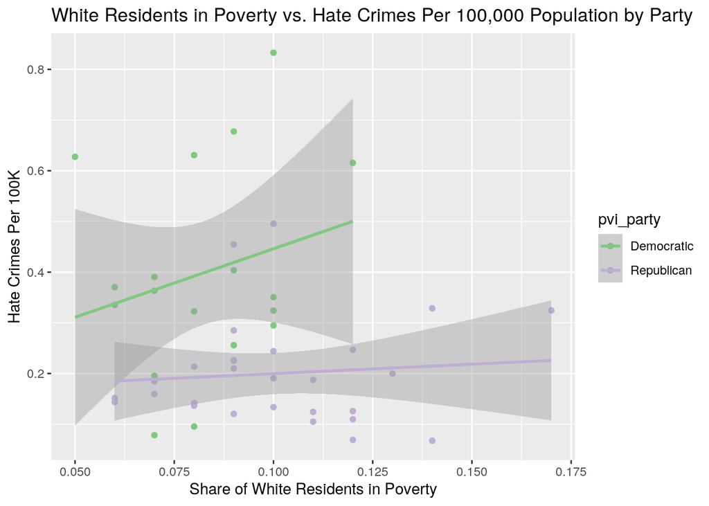

```r
# white residents in poverty vs. hate crimes scatterplot
innerdata %>% ggplot(aes(share_white_poverty, hate_crimes_per_100k_splc,
    color = pvi_party)) + ggtitle("White Residents in Poverty vs. Hate Crimes Per 100,000 Population by Party") +
    geom_point() + geom_smooth(method = "lm") + xlab("Share of White Residents in Poverty") +
    ylab("Hate Crimes Per 100K") + scale_color_brewer(palette = "Accent")
```

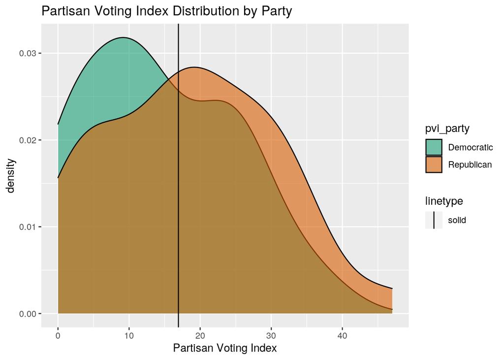

```r
# pvi_amount density plot by party
innerdata %>% group_by(pvi_party) %>% ggplot(aes(pvi_amount,
    fill = pvi_party)) + geom_density(alpha = 0.6) + ggtitle("Partisan Voting Index Distribution by Party") +
    xlab("Partisan Voting Index") + scale_fill_brewer(palette = "Dark2") +
    geom_vline(aes(xintercept = mean(pvi_amount), linetype = "solid"))
```

I created a density plot because I wanted to visualize the overlap of states partisan lean distributions in regards to their partisan voting index. There does in fact seem to be a lot of overlap between the Democratic and Republican parties. However the partisan voting index peak for the Democratic party is lower than the peak for the Republican party, meaning that the Republican party seems to have a higher PVI.

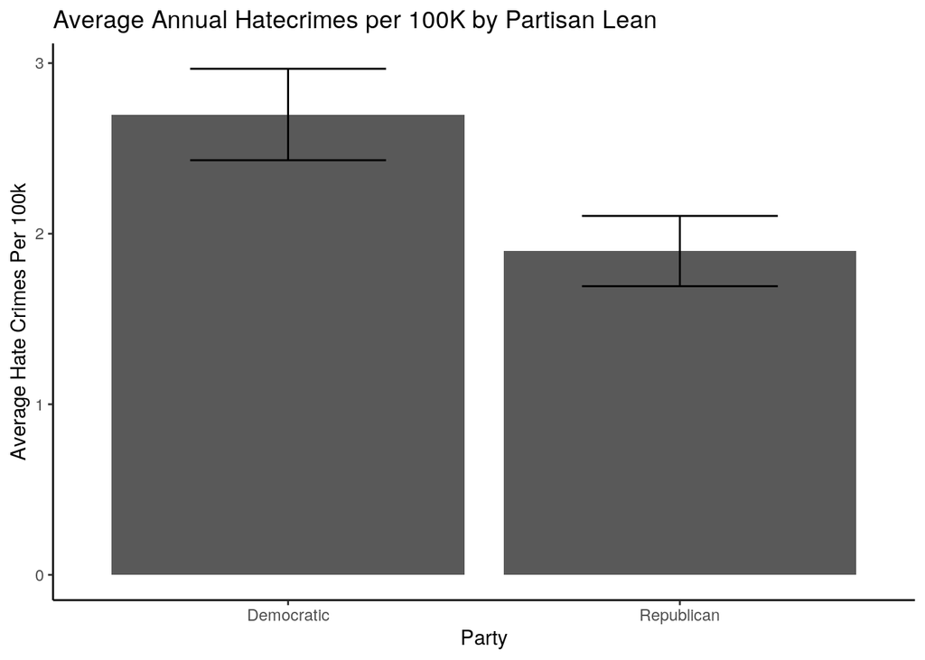

```r
# barplot of mean average annual hatecrimes per 100,000
# population by partisan lean
innerdata %>% ggplot(aes(x = pvi_party)) + geom_bar(aes(y = avg_hatecrimes_per_100k_fbi),
    stat = "summary", fun = mean) + ggtitle("Average Annual Hatecrimes per 100K by Partisan Lean") +
    xlab("Party") + ylab("Average Hate Crimes Per 100k") + theme_classic() +
    geom_errorbar(aes(y = avg_hatecrimes_per_100k_fbi), stat = "summary",
        fun.data = mean_se, width = 0.5)
```

I created a barplot to visualize the overall partisan lean from the dataset. I was interested to see which party (gathered from all states) was associated with the highest average hate crimes per 100,000 population. Again, I was surprised to see that the Democratic leaning states had the highest average hate crimes compared to the Republican leaning states average. Being able to visually see the data I was working with has been beneficial in explicitly showing the relationships between variables and the insights I now have from the data.

### Concluding Remarks

I started this data analysis project out of my interest in seeing the relationship between states partisan lean and hate crimes commited in the U.S. Some of the assumptions I had about what the results would look like were proven wrong, which was surprising, but beneficial towards my knowledge about both the topic and the process of data analysis.